# EDA Project

Ajay Kumar Upadhyay

10 June 2019

Questions:

Data Description:

Narrative Summary

Number of Observation

```
## [1] 41284
```

Number of variables - 6

Type of Variables - Country

```
## [1] "factor"
```

Year

```
## [1] "integer"
```

life

```
## [1] "numeric"
```

population

```
## [1] "factor"
```

income

```
## [1] "integer"
```

region

```
## [1] "factor"
```

How disperse is the data

```
##                 Country           Year           life
##  Afghanistan        :  216   Min.   :1800   Min.   : 1.00
##  Albania            :  216   1st Qu.:1854   1st Qu.:31.00
##  Algeria            :  216   Median :1908   Median :35.12
##  Angola             :  216   Mean   :1907   Mean   :42.88
##  Antigua and Barbuda:  216   3rd Qu.:1962   3rd Qu.:55.60
##  Argentina          :  216   Max.   :2015   Max.   :84.10
##  (Other)            :39988
##    population        income                              region
##         :25817   Min.   :   142   America                   : 7961
##  121000 :    6   1st Qu.:   883   East Asia & Pacific       : 6256
##  14092  :    6   Median :  1450   Europe & Central Asia     :10468
##  1432000:    6   Mean   :  4571   Middle East & North Africa: 4309
##  229000 :    6   3rd Qu.:  3483   South Asia                : 1728
##  2574000:    6   Max.   :182668   Sub-Saharan Africa        :10562
##  (Other):15437   NA's   :2341
```

Data wrangling

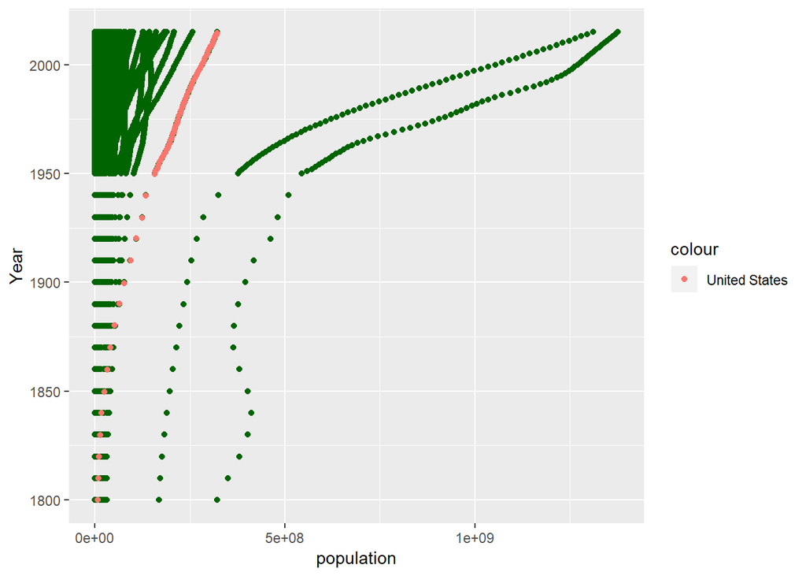

As shown from the graph above US has the 3rd largest population in the world. Population grew at a high rate after 1900

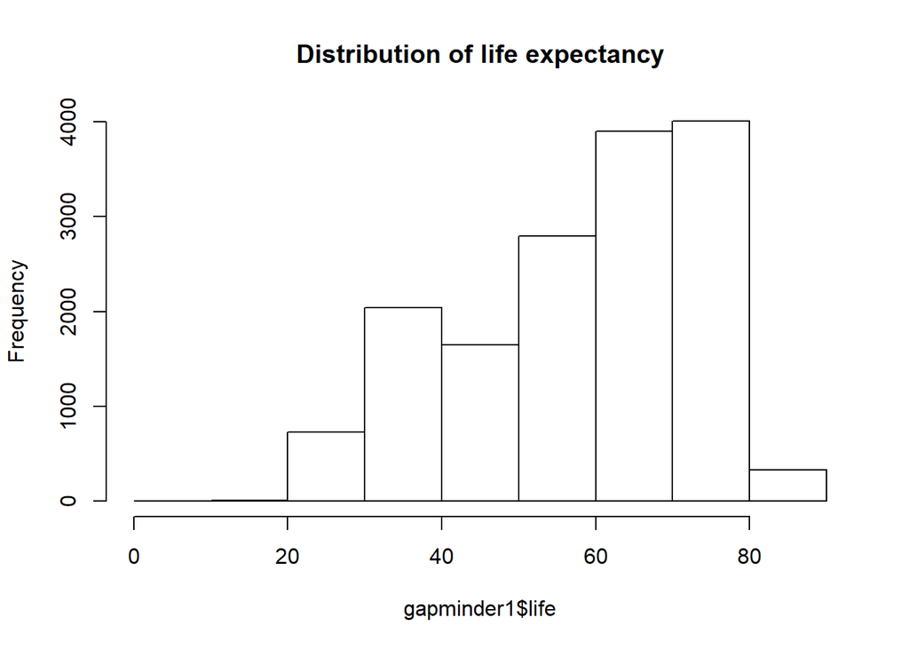

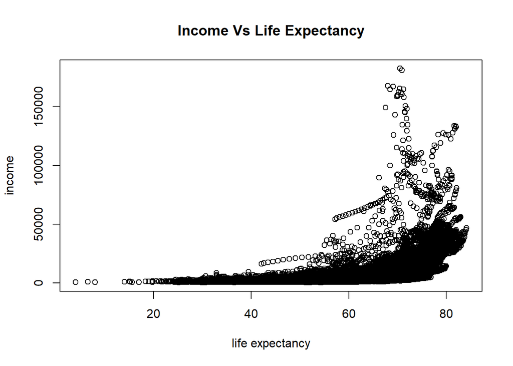

The scatterplot above shows that highes income relates to higher life expectancy

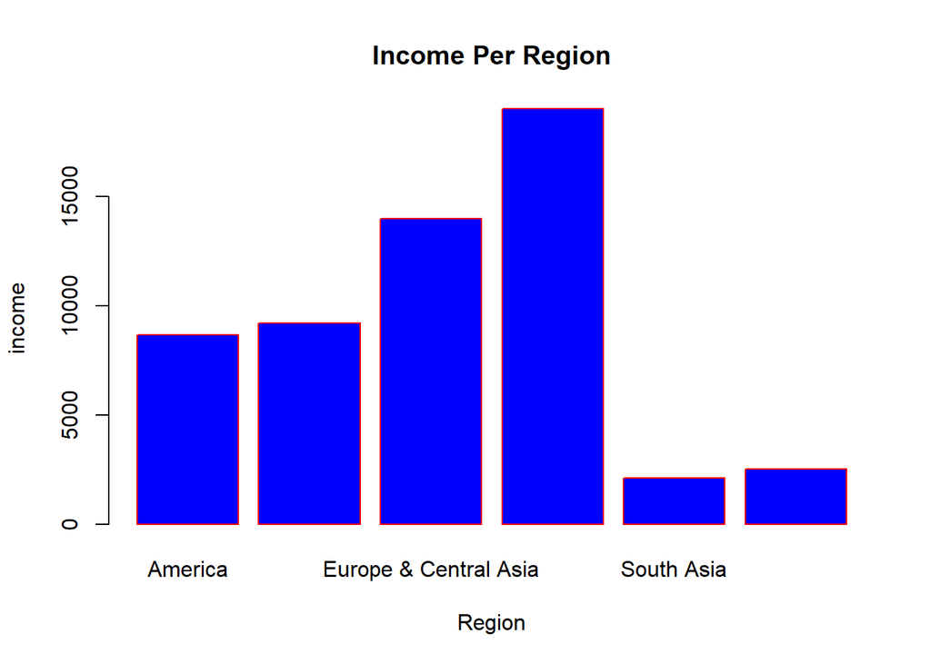

Above Bar plot shows the varian of mean income for different regions which shows that the highest mean income is from middle east and north africa region while the lowest is south asia

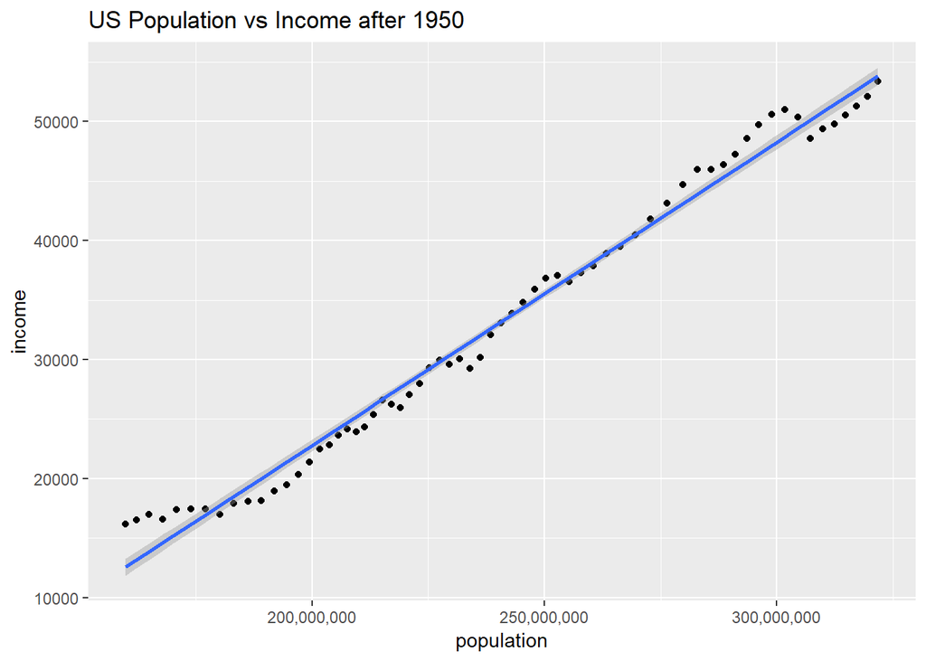

Above plot shows the population trend of US population vs income after 1950